# linreg3

## Linear Regression: Part 3

We are working with a dataset from a bike share company in Washington, DC. The data is contained in a CSV file (already uploaded in the Files pane at right). Let’s load the data and take a look at what we have.

```r
bike = read_csv("DC.csv")
```

Examine the dataset

```r
str(bike)
```

```
spc_tbl_ [17,379 × 17] (S3: spec_tbl_df/tbl_df/tbl/data.frame)
 $ instant   : num [1:17379] 1 2 3 4 5 6 7 8 9 10 ...
 $ dteday    : Date[1:17379], format: "2011-01-01" "2011-01-01" ...
 $ season    : num [1:17379] 1 1 1 1 1 1 1 1 1 1 ...
 $ yr        : num [1:17379] 0 0 0 0 0 0 0 0 0 0 ...
 $ mnth      : num [1:17379] 1 1 1 1 1 1 1 1 1 1 ...
 $ hr        : num [1:17379] 0 1 2 3 4 5 6 7 8 9 ...
 $ holiday   : num [1:17379] 0 0 0 0 0 0 0 0 0 0 ...
 $ weekday   : num [1:17379] 6 6 6 6 6 6 6 6 6 6 ...
 $ workingday: num [1:17379] 0 0 0 0 0 0 0 0 0 0 ...
 $ weathersit: num [1:17379] 1 1 1 1 1 2 1 1 1 1 ...
 $ temp      : num [1:17379] 0.24 0.22 0.22 0.24 0.24 0.24 0.22 0.2 0.24 0.32 ...
 $ atemp     : num [1:17379] 0.288 0.273 0.273 0.288 0.288 ...
 $ hum       : num [1:17379] 0.81 0.8 0.8 0.75 0.75 0.75 0.8 0.86 0.75 0.76 ...
 $ windspeed : num [1:17379] 0 0 0 0 0 0.0896 0 0 0 0 ...
 $ casual    : num [1:17379] 3 8 5 3 0 0 2 1 1 8 ...
 $ registered: num [1:17379] 13 32 27 10 1 1 0 2 7 6 ...
 $ count     : num [1:17379] 16 40 32 13 1 1 2 3 8 14 ...
 - attr(*, "spec")=
  .. cols(
  ..   instant = col_double(),
  ..   dteday = col_date(format = ""),
  ..   season = col_double(),
  ..   yr = col_double(),
  ..   mnth = col_double(),
  ..   hr = col_double(),
  ..   holiday = col_double(),
  ..   weekday = col_double(),
  ..   workingday = col_double(),
  ..   weathersit = col_double(),
  ..   temp = col_double(),
  ..   atemp = col_double(),
  ..   hum = col_double(),
  ..   windspeed = col_double(),
  ..   casual = col_double(),
  ..   registered = col_double(),
  ..   count = col_double()
  .. )
 - attr(*, "problems")=<externalptr>
```

This dataset will need a little love and care before it’s ready for analysis.

Let’s start by deleting the “instant” variable (just a row number; not needed)

```r
bike = bike %>% select(-instant)
```

What other things should do to this dataset before moving on to analysis?

Here’s a suggested list of cleaning tasks:

- Convert season, yr, month, hr, holiday, weekday, workingday, and weathersit to factors
- Rename the levels of these variable to be more user-friendly
- Handle missing data (if any)

```r
bike = bike %>% mutate(season = as_factor(season)) %>%
  mutate(yr = as_factor(yr)) %>%
  mutate(mnth = as_factor(mnth)) %>%
  mutate(hr = as_factor(hr)) %>%
  mutate(holiday = as_factor(holiday)) %>%
  mutate(weekday = as_factor(weekday)) %>%
  mutate(workingday = as_factor(workingday)) %>%
  mutate(weathersit = as_factor(weathersit))

str(bike)
```

```
tibble [17,379 × 16] (S3: tbl_df/tbl/data.frame)
 $ dteday    : Date[1:17379], format: "2011-01-01" "2011-01-01" ...
 $ season    : Factor w/ 4 levels "1","2","3","4": 1 1 1 1 1 1 1 1 1 1 ...
 $ yr        : Factor w/ 2 levels "0","1": 1 1 1 1 1 1 1 1 1 1 ...
 $ mnth      : Factor w/ 12 levels "1","2","3","4",..: 1 1 1 1 1 1 1 1 1 1 ...
 $ hr        : Factor w/ 24 levels "0","1","2","3",..: 1 2 3 4 5 6 7 8 9 10 ...
 $ holiday   : Factor w/ 2 levels "0","1": 1 1 1 1 1 1 1 1 1 1 ...
 $ weekday   : Factor w/ 7 levels "0","1","2","3",..: 7 7 7 7 7 7 7 7 7 7 ...
 $ workingday: Factor w/ 2 levels "0","1": 1 1 1 1 1 1 1 1 1 1 ...
 $ weathersit: Factor w/ 4 levels "1","2","3","4": 1 1 1 1 1 2 1 1 1 1 ...
 $ temp      : num [1:17379] 0.24 0.22 0.22 0.24 0.24 0.24 0.22 0.2 0.24 0.32 ...
 $ atemp     : num [1:17379] 0.288 0.273 0.273 0.288 0.288 ...
 $ hum       : num [1:17379] 0.81 0.8 0.8 0.75 0.75 0.75 0.8 0.86 0.75 0.76 ...
 $ windspeed : num [1:17379] 0 0 0 0 0 0.0896 0 0 0 0 ...
 $ casual    : num [1:17379] 3 8 5 3 0 0 2 1 1 8 ...
 $ registered: num [1:17379] 13 32 27 10 1 1 0 2 7 6 ...
 $ count     : num [1:17379] 16 40 32 13 1 1 2 3 8 14 ...
```

Rename factor levels for the season, month, weekday, and weathersit variables.

```r
bike = bike %>% mutate(season = fct_recode(season, "Winter" = "1",
                                           "Spring" = "2",
                                           "Summer" = "3",
                                           "Fall" = "4")) %>%
  mutate(mnth = fct_recode(mnth, "Jan" = "1",
                           "Feb" = "2",
                           "Mar" = "3",
                           "Apr" = "4",
                           "May" = "5",
                           "Jun" = "6",
                           "Jul" = "7",
                           "Aug" = "8",
                           "Sep" = "9",
                           "Oct" = "10",
                           "Nov" = "11",
                           "Dec" = "12")) %>%
  mutate(weekday = fct_recode(weekday, "Sun" = "0",
                              "Mon" = "1",
                              "Tue" = "2",
                              "Wed" = "3",
                              "Thu" = "4",
                              "Fri" = "5",
                              "Sat" = "6")) %>%
  mutate(weathersit = fct_recode(weathersit, "Clear" = "1",
                                 "Mist" = "2",
                                 "Lt Precip" = "3",
                                 "Heavy Precip" = "4"))

str(bike)
```

```
tibble [17,379 × 16] (S3: tbl_df/tbl/data.frame)
 $ dteday    : Date[1:17379], format: "2011-01-01" "2011-01-01" ...
 $ season    : Factor w/ 4 levels "Winter","Spring",..: 1 1 1 1 1 1 1 1 1 1 ...
 $ yr        : Factor w/ 2 levels "0","1": 1 1 1 1 1 1 1 1 1 1 ...
 $ mnth      : Factor w/ 12 levels "Jan","Feb","Mar",..: 1 1 1 1 1 1 1 1 1 1 ...
 $ hr        : Factor w/ 24 levels "0","1","2","3",..: 1 2 3 4 5 6 7 8 9 10 ...
 $ holiday   : Factor w/ 2 levels "0","1": 1 1 1 1 1 1 1 1 1 1 ...
 $ weekday   : Factor w/ 7 levels "Sun","Mon","Tue",..: 7 7 7 7 7 7 7 7 7 7 ...
 $ workingday: Factor w/ 2 levels "0","1": 1 1 1 1 1 1 1 1 1 1 ...
 $ weathersit: Factor w/ 4 levels "Clear","Mist",..: 1 1 1 1 1 2 1 1 1 1 ...
 $ temp      : num [1:17379] 0.24 0.22 0.22 0.24 0.24 0.24 0.22 0.2 0.24 0.32 ...
 $ atemp     : num [1:17379] 0.288 0.273 0.273 0.288 0.288 ...
 $ hum       : num [1:17379] 0.81 0.8 0.8 0.75 0.75 0.75 0.8 0.86 0.75 0.76 ...
 $ windspeed : num [1:17379] 0 0 0 0 0 0.0896 0 0 0 0 ...
 $ casual    : num [1:17379] 3 8 5 3 0 0 2 1 1 8 ...
 $ registered: num [1:17379] 13 32 27 10 1 1 0 2 7 6 ...
 $ count     : num [1:17379] 16 40 32 13 1 1 2 3 8 14 ...
```

Is there missing data?

```r
skim(bike)
```

Data summary

| Name | bike |
| --- | --- |
| Number of rows | 17379 |
| Number of columns | 16 |
| _______________________ |  |
| Column type frequency: |  |
| Date | 1 |
| factor | 8 |
| numeric | 7 |
| ________________________ |  |
| Group variables | None |

**Variable type: Date**

| skim_variable | n_missing | complete_rate | min | max | median | n_unique |
| --- | --- | --- | --- | --- | --- | --- |
| dteday | 0 | 1 | 2011-01-01 | 2012-12-31 | 2012-01-02 | 731 |

**Variable type: factor**

| skim_variable | n_missing | complete_rate | ordered | n_unique | top_counts |
| --- | --- | --- | --- | --- | --- |
| season | 0 | 1 | FALSE | 4 | Sum: 4496, Spr: 4409, Win: 4242, Fal: 4232 |
| yr | 0 | 1 | FALSE | 2 | 1: 8734, 0: 8645 |
| mnth | 0 | 1 | FALSE | 12 | May: 1488, Jul: 1488, Dec: 1483, Aug: 1475 |
| hr | 0 | 1 | FALSE | 24 | 16: 730, 17: 730, 13: 729, 14: 729 |
| holiday | 0 | 1 | FALSE | 2 | 0: 16879, 1: 500 |
| weekday | 0 | 1 | FALSE | 7 | Sat: 2512, Sun: 2502, Fri: 2487, Mon: 2479 |
| workingday | 0 | 1 | FALSE | 2 | 1: 11865, 0: 5514 |
| weathersit | 0 | 1 | FALSE | 4 | Cle: 11413, Mis: 4544, Lt : 1419, Hea: 3 |

**Variable type: numeric**

| skim_variable | n_missing | complete_rate | mean | sd | p0 | p25 | p50 | p75 | p100 | hist |
| --- | --- | --- | --- | --- | --- | --- | --- | --- | --- | --- |
| temp | 0 | 1 | 0.50 | 0.19 | 0.02 | 0.34 | 0.50 | 0.66 | 1.00 | ▂▇▇▇▁ |
| atemp | 0 | 1 | 0.48 | 0.17 | 0.00 | 0.33 | 0.48 | 0.62 | 1.00 | ▁▆▇▆▁ |
| hum | 0 | 1 | 0.63 | 0.19 | 0.00 | 0.48 | 0.63 | 0.78 | 1.00 | ▁▃▇▇▆ |
| windspeed | 0 | 1 | 0.19 | 0.12 | 0.00 | 0.10 | 0.19 | 0.25 | 0.85 | ▇▆▂▁▁ |
| casual | 0 | 1 | 35.68 | 49.31 | 0.00 | 4.00 | 17.00 | 48.00 | 367.00 | ▇▁▁▁▁ |
| registered | 0 | 1 | 153.79 | 151.36 | 0.00 | 34.00 | 115.00 | 220.00 | 886.00 | ▇▃▁▁▁ |
| count | 0 | 1 | 189.46 | 181.39 | 1.00 | 40.00 | 142.00 | 281.00 | 977.00 | ▇▃▁▁▁ |

No missingness.

Data cleaning and prep is complete so off we go to correlation and visualization.

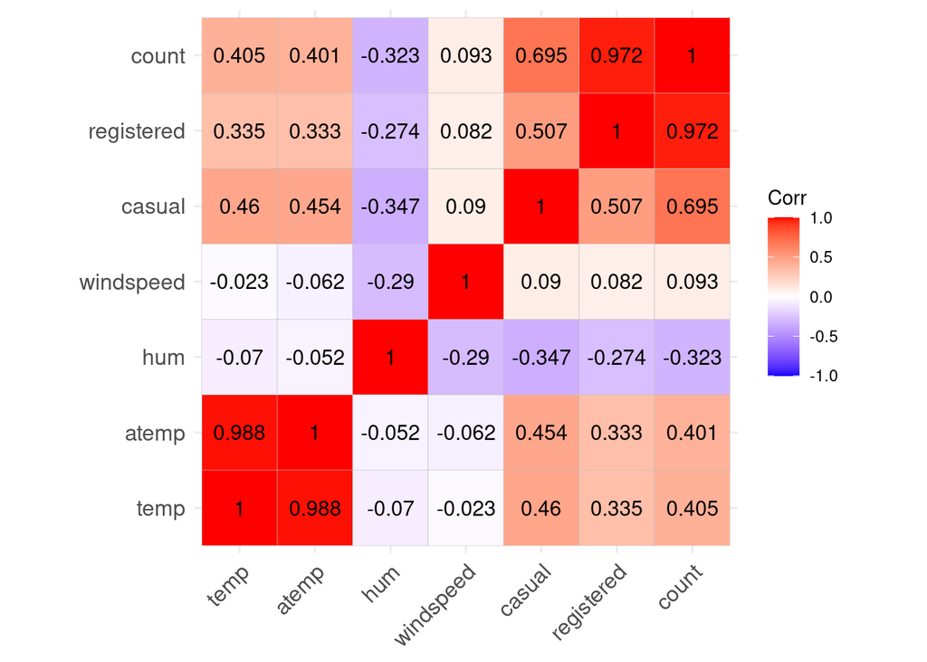

```r
corr = bike %>% select_if(is.numeric) %>% cor(.)
ggcorrplot(corr, lab = TRUE, digits = 3)
```

BIG NOTE: We can ignore “registered” and “casual” as the “count” variable is the sum of these two variables. We cannot use these variables in our models to predict count. That puts “temp” as our strongest numeric variable. Followed closely by “atemp”. Note that temp and atemp are strongly correlated with each other! This can cause issues if we are not careful!

Let’s do our visuals.

## Alpha = transparency

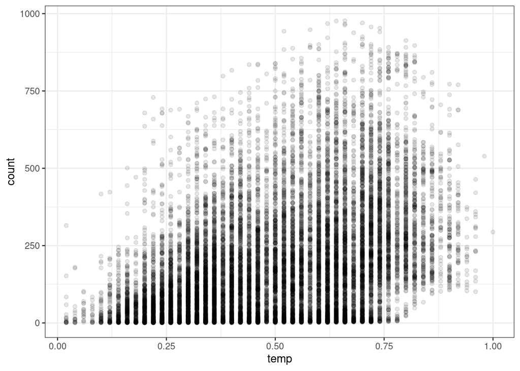

```r
ggplot(bike, aes(x=temp, y=count)) + geom_point(alpha = 0.1) + theme_bw()
```

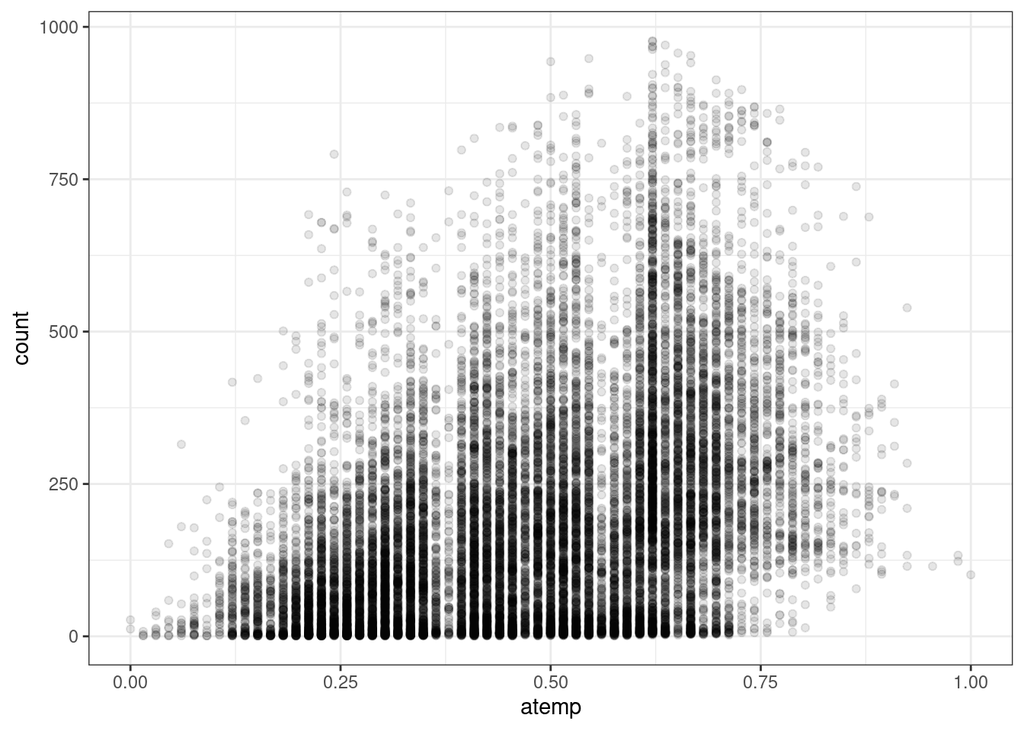

```r
ggplot(bike, aes(x=atemp, y=count)) + geom_point(alpha = 0.1) + theme_bw()
```

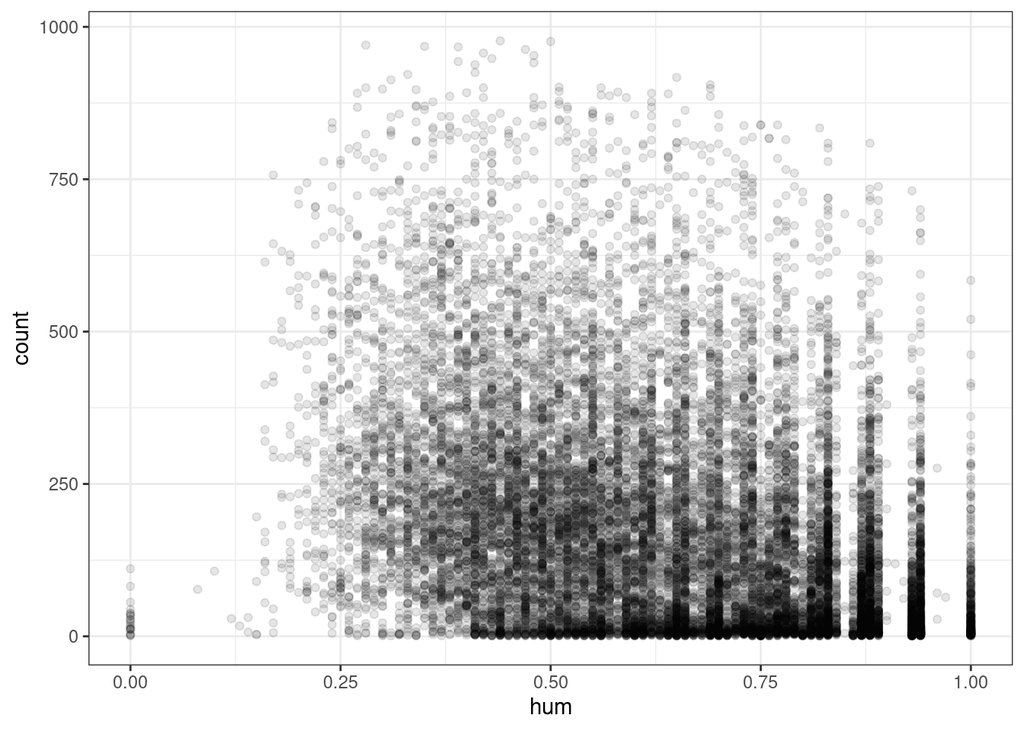

```r
ggplot(bike, aes(x=hum, y=count)) + geom_point(alpha = 0.1) + theme_bw()
```

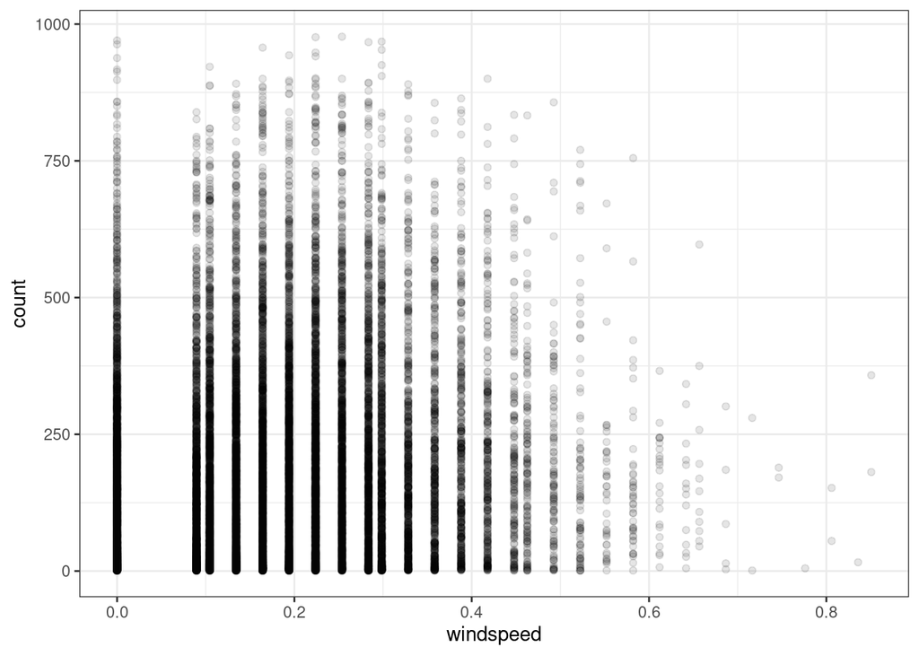

```r
ggplot(bike, aes(x=windspeed, y=count)) + geom_point(alpha = 0.1) + theme_bw()
```

Now categorical.

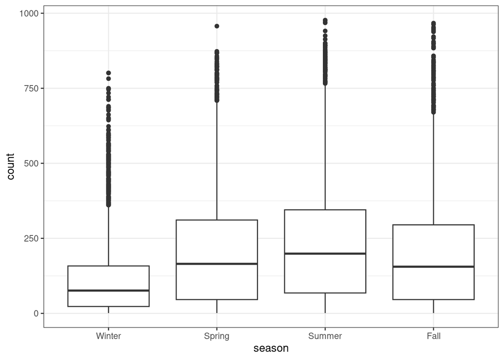

```r
ggplot(bike, aes(x=season, y=count)) + geom_boxplot() + theme_bw()
```

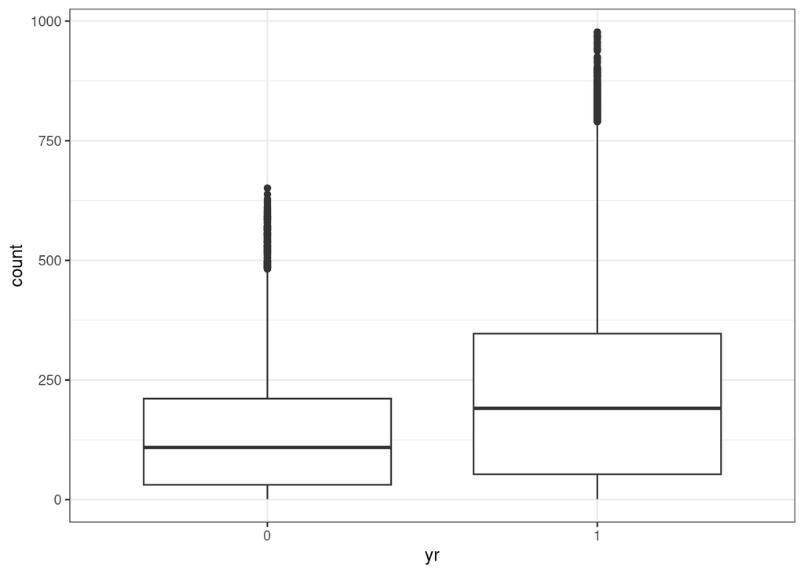

```r
ggplot(bike, aes(x=yr, y=count)) + geom_boxplot() + theme_bw()
```

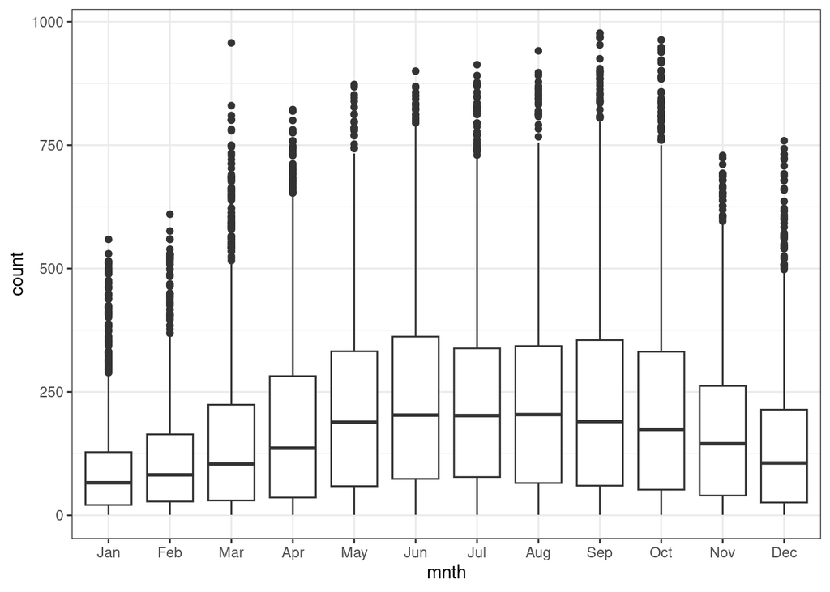

```r
ggplot(bike, aes(x=mnth, y=count)) + geom_boxplot() + theme_bw()
```

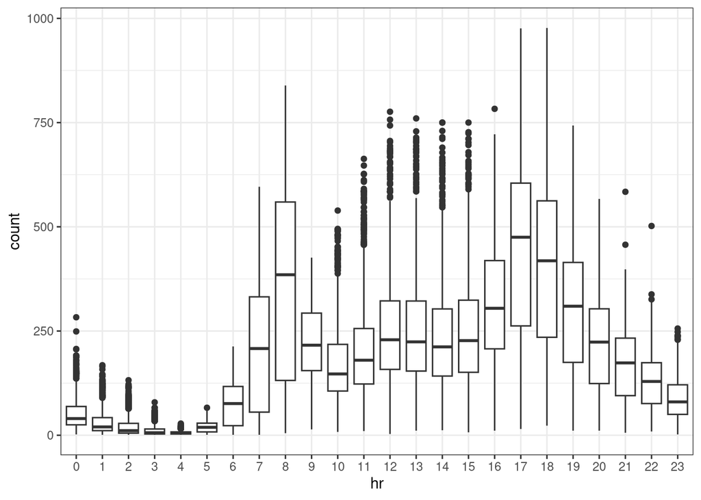

```r
ggplot(bike, aes(x=hr, y=count)) + geom_boxplot() + theme_bw()
```

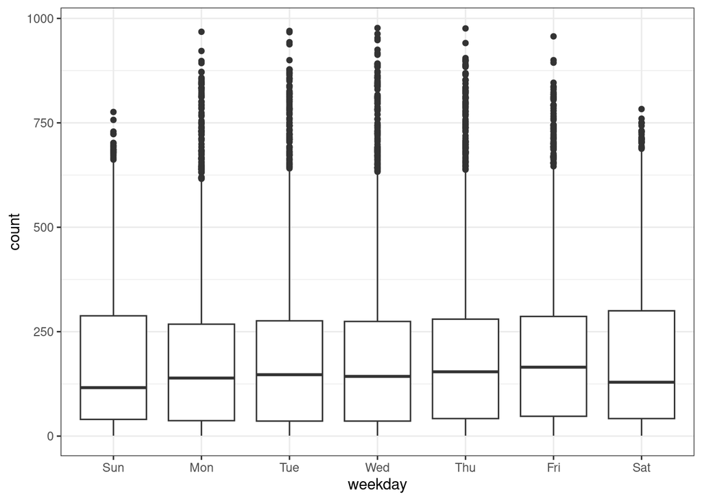

```r
ggplot(bike, aes(x=weekday, y=count)) + geom_boxplot() + theme_bw()
```

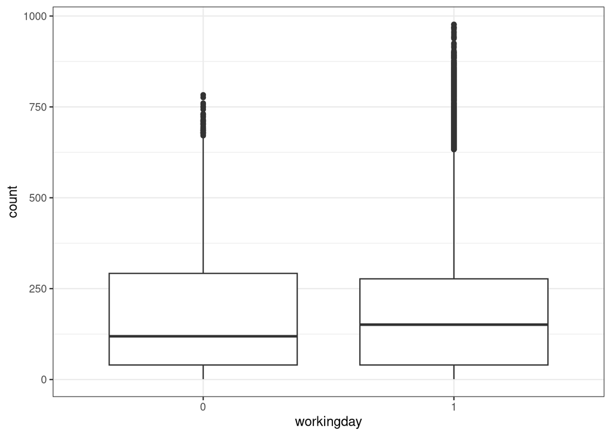

```r
ggplot(bike, aes(x=workingday, y=count)) + geom_boxplot() + theme_bw()
```

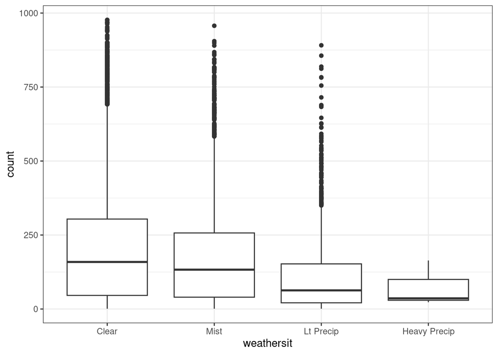

```r
ggplot(bike, aes(x=weathersit, y=count)) + geom_boxplot() + theme_bw()
```

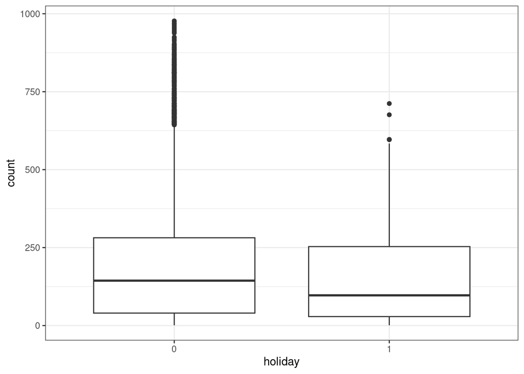

```r
ggplot(bike, aes(x=holiday, y=count)) + geom_boxplot() + theme_bw()
```

We won’t use the date variable as a predictor, but we can plot it if we wish.

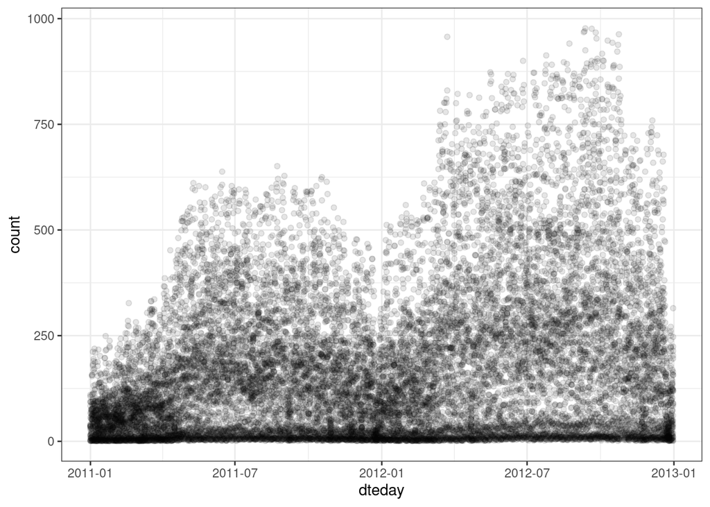

```r
ggplot(bike, aes(x=dteday, y=count)) + geom_point(alpha = 0.1) + theme_bw()
```

## Forward selection

It’s model building time. We can utilize forward selection (add one variable at a time). This may prove tricky since we have so many categorical variables. Let’s get started.

Let’s build a model with temp to predict count.

```r
model1 = lm(count ~ temp, bike)
```

```r
summary(model1)
```

```
Call:
lm(formula = count ~ temp, data = bike)

Residuals:
    Min      1Q  Median      3Q     Max
-291.37 -110.23  -32.86   76.77  744.76

Coefficients:
            Estimate Std. Error t value Pr(>|t|)
(Intercept)  -0.0356     3.4827   -0.01    0.992
temp        381.2949     6.5344   58.35   <2e-16 ***
---
Signif. codes:  0 '***' 0.001 '**' 0.01 '*' 0.05 '.' 0.1 ' ' 1

Residual standard error: 165.9 on 17377 degrees of freedom
Multiple R-squared:  0.1638,    Adjusted R-squared:  0.1638
F-statistic:  3405 on 1 and 17377 DF,  p-value: < 2.2e-16
```

How do we feel about this model?

Let’s add atemp.

```r
model2 = lm(count ~ temp + atemp, bike)
```

```r
summary(model2)
```

```
Call:
lm(formula = count ~ temp + atemp, data = bike)

Residuals:
    Min      1Q  Median      3Q     Max
-293.47 -109.95  -32.87   76.57  744.57

Coefficients:
            Estimate Std. Error t value Pr(>|t|)
(Intercept)   -1.898      3.904  -0.486    0.627
temp         337.744     41.744   8.091 6.31e-16 ***
atemp         49.407     46.773   1.056    0.291
---
Signif. codes:  0 '***' 0.001 '**' 0.01 '*' 0.05 '.' 0.1 ' ' 1

Residual standard error: 165.9 on 17376 degrees of freedom
Multiple R-squared:  0.1639,    Adjusted R-squared:  0.1638
F-statistic:  1703 on 2 and 17376 DF,  p-value: < 2.2e-16
```

Here we see evidence of a phenomenon known as **multicollinearity**. This can occur when two or more of our predictors are strongly correlated with each other. In this model, temp and atemp are very strongly correlated. Because of this, atemp gets “pushed” out of the model. We can skip inclusion of atemp.

Let’s add some of our categorical variables to see how the model improves.

```r
model3 = lm(count ~ temp + hr, bike)
```

```r
summary(model3)
```

```
Call:
lm(formula = count ~ temp + hr, data = bike)

Residuals:
    Min      1Q  Median      3Q     Max
-469.96  -63.29   -6.93   52.41  519.88

Coefficients:
            Estimate Std. Error t value Pr(>|t|)
(Intercept)  -80.181      4.848 -16.539  < 2e-16 ***
temp         286.855      4.715  60.836  < 2e-16 ***
hr1          -18.214      6.111  -2.981  0.00288 **
hr2          -27.346      6.131  -4.461 8.22e-06 ***
hr3          -38.069      6.170  -6.170 6.99e-10 ***
hr4          -41.584      6.171  -6.739 1.65e-11 ***
hr5          -25.033      6.128  -4.085 4.42e-05 ***
hr6           32.169      6.111   5.264 1.43e-07 ***
hr7          166.290      6.106  27.233  < 2e-16 ***
hr8          308.675      6.105  50.561  < 2e-16 ***
hr9          162.739      6.105  26.657  < 2e-16 ***
hr10         110.256      6.107  18.055  < 2e-16 ***
hr11         138.410      6.110  22.652  < 2e-16 ***
hr12         178.516      6.112  29.206  < 2e-16 ***
hr13         174.714      6.114  28.574  < 2e-16 ***
hr14         159.035      6.118  25.995  < 2e-16 ***
hr15         168.304      6.119  27.505  < 2e-16 ***
hr16         230.103      6.116  37.625  < 2e-16 ***
hr17         382.550      6.112  62.588  < 2e-16 ***
hr18         350.451      6.112  57.334  < 2e-16 ***
hr19         241.342      6.108  39.510  < 2e-16 ***
hr20         160.317      6.106  26.257  < 2e-16 ***
hr21         110.416      6.104  18.089  < 2e-16 ***
hr22          72.533      6.103  11.885  < 2e-16 ***
hr23          31.748      6.103   5.202 1.99e-07 ***
---
Signif. codes:  0 '***' 0.001 '**' 0.01 '*' 0.05 '.' 0.1 ' ' 1

Residual standard error: 116.3 on 17354 degrees of freedom
Multiple R-squared:  0.5891,    Adjusted R-squared:  0.5886
F-statistic:  1037 on 24 and 17354 DF,  p-value: < 2.2e-16
```

## Hr 17 is bumping, this is peak ride time

[ex. 1 temp at 4 AM => (286.855*1) - (41.584*1) - 80.181(intercept) = 165.09 rides]

How about this model?

```r
model4 = lm(count ~ temp + hr + mnth, bike)
```

```r
summary(model4)
```

```
Call:
lm(formula = count ~ temp + hr + mnth, data = bike)

Residuals:
    Min      1Q  Median      3Q     Max
-455.39  -62.42   -8.35   53.15  503.19

Coefficients:
             Estimate Std. Error t value Pr(>|t|)
(Intercept) -108.2742     5.5862 -19.382  < 2e-16 ***
temp         309.7458    10.3487  29.931  < 2e-16 ***
hr1          -17.9599     6.0281  -2.979 0.002892 **
hr2          -27.0515     6.0484  -4.472 7.78e-06 ***
hr3          -37.9579     6.0900  -6.233 4.69e-10 ***
hr4          -41.4714     6.0928  -6.807 1.03e-11 ***
hr5          -24.4202     6.0522  -4.035 5.49e-05 ***
hr6           33.0197     6.0363   5.470 4.56e-08 ***
hr7          167.0353     6.0284  27.708  < 2e-16 ***
hr8          309.0564     6.0227  51.316  < 2e-16 ***
hr9          162.6232     6.0221  27.005  < 2e-16 ***
hr10         109.5943     6.0310  18.172  < 2e-16 ***
hr11         137.2433     6.0483  22.691  < 2e-16 ***
hr12         176.9695     6.0667  29.171  < 2e-16 ***
hr13         172.7868     6.0852  28.395  < 2e-16 ***
hr14         156.8712     6.1020  25.708  < 2e-16 ***
hr15         166.0589     6.1082  27.186  < 2e-16 ***
hr16         227.9653     6.1004  37.369  < 2e-16 ***
hr17         380.6501     6.0834  62.572  < 2e-16 ***
hr18         348.8113     6.0683  57.481  < 2e-16 ***
hr19         240.0911     6.0485  39.695  < 2e-16 ***
hr20         159.4228     6.0348  26.417  < 2e-16 ***
hr21         109.8258     6.0265  18.224  < 2e-16 ***
hr22          72.1906     6.0220  11.988  < 2e-16 ***
hr23          31.6223     6.0198   5.253 1.51e-07 ***
mnthFeb       -0.6053     4.4114  -0.137 0.890869
mnthMar       15.4300     4.5497   3.391 0.000697 ***
mnthApr       24.0637     4.9220   4.889 1.02e-06 ***
mnthMay       21.4044     5.6419   3.794 0.000149 ***
mnthJun       11.3525     6.3116   1.799 0.072089 .
mnthJul      -19.4504     6.8507  -2.839 0.004528 **
mnthAug        0.7799     6.4827   0.120 0.904248
mnthSep       32.2265     5.8185   5.539 3.09e-08 ***
mnthOct       53.4911     5.0019  10.694  < 2e-16 ***
mnthNov       45.3771     4.5023  10.079  < 2e-16 ***
mnthDec       24.0691     4.3499   5.533 3.19e-08 ***
---
Signif. codes:  0 '***' 0.001 '**' 0.01 '*' 0.05 '.' 0.1 ' ' 1

Residual standard error: 114.8 on 17343 degrees of freedom
Multiple R-squared:  0.6005,    Adjusted R-squared:  0.5997
F-statistic: 744.9 on 35 and 17343 DF,  p-value: < 2.2e-16
```

How about this model?

As we proceed, I’m thinking to not include season as month captures that concept. Let’s add weekday.

```r
model5 = lm(count ~ temp + hr + mnth + weekday, bike)
```

```r
summary(model5)
```

```
Call:
lm(formula = count ~ temp + hr + mnth + weekday, data = bike)

Residuals:
    Min      1Q  Median      3Q     Max
-461.57  -62.48   -8.82   53.02  509.53

Coefficients:
             Estimate Std. Error t value Pr(>|t|)
(Intercept) -115.6809     5.9164 -19.553  < 2e-16 ***
temp         309.7539    10.3888  29.816  < 2e-16 ***
hr1          -17.9704     6.0226  -2.984 0.002851 **
hr2          -27.1154     6.0430  -4.487 7.27e-06 ***
hr3          -38.0088     6.0846  -6.247 4.29e-10 ***
hr4          -41.4819     6.0874  -6.814 9.78e-12 ***
hr5          -24.4738     6.0469  -4.047 5.20e-05 ***
hr6           33.0066     6.0310   5.473 4.49e-08 ***
hr7          167.0431     6.0231  27.734  < 2e-16 ***
hr8          309.0641     6.0172  51.363  < 2e-16 ***
hr9          162.6307     6.0166  27.030  < 2e-16 ***
hr10         109.6016     6.0257  18.189  < 2e-16 ***
hr11         137.2505     6.0431  22.712  < 2e-16 ***
hr12         176.9796     6.0617  29.197  < 2e-16 ***
hr13         172.8002     6.0803  28.420  < 2e-16 ***
hr14         156.8845     6.0973  25.730  < 2e-16 ***
hr15         166.0722     6.1035  27.209  < 2e-16 ***
hr16         227.9732     6.0957  37.399  < 2e-16 ***
hr17         380.6580     6.0785  62.623  < 2e-16 ***
hr18         348.8263     6.0632  57.532  < 2e-16 ***
hr19         240.1062     6.0432  39.731  < 2e-16 ***
hr20         159.4380     6.0294  26.443  < 2e-16 ***
hr21         109.8411     6.0211  18.243  < 2e-16 ***
hr22          72.2060     6.0166  12.001  < 2e-16 ***
hr23          31.6378     6.0144   5.260 1.46e-07 ***
mnthFeb       -0.9647     4.4085  -0.219 0.826780
mnthMar       14.7770     4.5476   3.249 0.001159 **
mnthApr       23.6845     4.9226   4.811 1.51e-06 ***
mnthMay       21.2992     5.6428   3.775 0.000161 ***
mnthJun       10.7314     6.3185   1.698 0.089447 .
mnthJul      -19.6558     6.8633  -2.864 0.004190 **
mnthAug        0.4029     6.4867   0.062 0.950479
mnthSep       31.7070     5.8245   5.444 5.29e-08 ***
mnthOct       53.2858     5.0019  10.653  < 2e-16 ***
mnthNov       44.9066     4.4995   9.980  < 2e-16 ***
mnthDec       23.5265     4.3475   5.412 6.33e-08 ***
weekdayMon     2.7196     3.2521   0.836 0.403018
weekdayTue     5.1355     3.2663   1.572 0.115911
weekdayWed     6.2615     3.2593   1.921 0.054735 .
weekdayThu    11.3594     3.2614   3.483 0.000497 ***
weekdayFri    14.9329     3.2495   4.595 4.35e-06 ***
weekdaySat    13.9477     3.2393   4.306 1.67e-05 ***
---
Signif. codes:  0 '***' 0.001 '**' 0.01 '*' 0.05 '.' 0.1 ' ' 1

Residual standard error: 114.7 on 17337 degrees of freedom
Multiple R-squared:  0.6014,    Adjusted R-squared:  0.6004
F-statistic: 637.9 on 41 and 17337 DF,  p-value: < 2.2e-16
```

```r
model6 = lm(count ~ temp + hr + mnth + weekday + holiday, bike)
```

```r
summary(model6)
```

```
Call:
lm(formula = count ~ temp + hr + mnth + weekday + holiday, data = bike)

Residuals:
    Min      1Q  Median      3Q     Max
-460.43  -62.59   -8.83   52.86  509.61

Coefficients:
            Estimate Std. Error t value Pr(>|t|)
(Intercept) -115.669      5.912 -19.565  < 2e-16 ***
temp         312.239     10.392  30.047  < 2e-16 ***
hr1          -17.944      6.018  -2.982 0.002870 **
hr2          -27.043      6.038  -4.479 7.56e-06 ***
hr3          -38.007      6.080  -6.251 4.17e-10 ***
hr4          -41.400      6.083  -6.806 1.04e-11 ***
hr5          -24.384      6.042  -4.035 5.47e-05 ***
hr6           33.100      6.026   5.492 4.02e-08 ***
hr7          167.120      6.019  27.768  < 2e-16 ***
hr8          309.101      6.013  51.408  < 2e-16 ***
hr9          162.614      6.012  27.048  < 2e-16 ***
hr10         109.526      6.021  18.190  < 2e-16 ***
hr11         137.120      6.039  22.707  < 2e-16 ***
hr12         176.803      6.057  29.189  < 2e-16 ***
hr13         172.587      6.076  28.406  < 2e-16 ***
hr14         156.646      6.093  25.710  < 2e-16 ***
hr15         165.825      6.099  27.188  < 2e-16 ***
hr16         227.732      6.091  37.387  < 2e-16 ***
hr17         380.443      6.074  62.634  < 2e-16 ***
hr18         348.645      6.059  57.544  < 2e-16 ***
hr19         239.967      6.039  39.738  < 2e-16 ***
hr20         159.337      6.025  26.446  < 2e-16 ***
hr21         109.774      6.017  18.245  < 2e-16 ***
hr22          72.165      6.012  12.003  < 2e-16 ***
hr23          31.621      6.010   5.261 1.45e-07 ***
mnthFeb       -1.459      4.406  -0.331 0.740614
mnthMar       13.095      4.556   2.874 0.004053 **
mnthApr       22.689      4.923   4.609 4.07e-06 ***
mnthMay       19.972      5.644   3.539 0.000403 ***
mnthJun        8.301      6.331   1.311 0.189811
mnthJul      -21.374      6.866  -3.113 0.001855 **
mnthAug       -2.144      6.500  -0.330 0.741514
mnthSep       30.405      5.825   5.219 1.82e-07 ***
mnthOct       52.242      5.002  10.444  < 2e-16 ***
mnthNov       45.164      4.496  10.045  < 2e-16 ***
mnthDec       22.843      4.346   5.256 1.49e-07 ***
weekdayMon     6.814      3.343   2.038 0.041524 *
weekdayTue     5.373      3.264   1.646 0.099776 .
weekdayWed     6.531      3.257   2.005 0.044987 *
weekdayThu    11.904      3.261   3.651 0.000262 ***
weekdayFri    15.490      3.249   4.768 1.88e-06 ***
weekdaySat    13.968      3.237   4.315 1.60e-05 ***
holiday1     -28.546      5.468  -5.220 1.81e-07 ***
---
Signif. codes:  0 '***' 0.001 '**' 0.01 '*' 0.05 '.' 0.1 ' ' 1

Residual standard error: 114.6 on 17336 degrees of freedom
Multiple R-squared:  0.602, Adjusted R-squared:  0.601
F-statistic: 624.3 on 42 and 17336 DF,  p-value: < 2.2e-16
```

```r
model7 = lm(count ~ temp + hr + mnth + weekday + holiday + weathersit, bike)
```

```r
summary(model7)
```

```
Call:
lm(formula = count ~ temp + hr + mnth + weekday + holiday + weathersit,
    data = bike)

Residuals:
    Min      1Q  Median      3Q     Max
-396.52  -62.55   -9.54   51.76  494.63

Coefficients:
                       Estimate Std. Error t value Pr(>|t|)
(Intercept)            -101.775      5.810 -17.518  < 2e-16 ***
temp                    291.495     10.184  28.622  < 2e-16 ***
hr1                     -17.864      5.880  -3.038 0.002382 **
hr2                     -26.753      5.899  -4.535 5.79e-06 ***
hr3                     -37.570      5.940  -6.325 2.59e-10 ***
hr4                     -40.831      5.942  -6.871 6.58e-12 ***
hr5                     -24.792      5.903  -4.200 2.69e-05 ***
hr6                      33.598      5.888   5.706 1.17e-08 ***
hr7                     169.527      5.881  28.829  < 2e-16 ***
hr8                     310.731      5.875  52.889  < 2e-16 ***
hr9                     164.587      5.875  28.013  < 2e-16 ***
hr10                    111.503      5.883  18.952  < 2e-16 ***
hr11                    138.884      5.900  23.538  < 2e-16 ***
hr12                    179.840      5.919  30.385  < 2e-16 ***
hr13                    175.701      5.936  29.597  < 2e-16 ***
hr14                    159.983      5.953  26.873  < 2e-16 ***
hr15                    169.441      5.960  28.430  < 2e-16 ***
hr16                    231.017      5.954  38.800  < 2e-16 ***
hr17                    384.196      5.937  64.712  < 2e-16 ***
hr18                    351.677      5.921  59.391  < 2e-16 ***
hr19                    241.343      5.900  40.905  < 2e-16 ***
hr20                    160.992      5.888  27.344  < 2e-16 ***
hr21                    110.250      5.878  18.756  < 2e-16 ***
hr22                     72.325      5.873  12.314  < 2e-16 ***
hr23                     33.209      5.872   5.656 1.57e-08 ***
mnthFeb                   1.050      4.309   0.244 0.807508
mnthMar                  16.911      4.454   3.797 0.000147 ***
mnthApr                  28.627      4.818   5.942 2.87e-09 ***
mnthMay                  28.319      5.526   5.125 3.01e-07 ***
mnthJun                  12.768      6.197   2.060 0.039396 *
mnthJul                 -16.372      6.723  -2.435 0.014891 *
mnthAug                   3.790      6.363   0.596 0.551456
mnthSep                  40.070      5.704   7.025 2.23e-12 ***
mnthOct                  60.218      4.898  12.295  < 2e-16 ***
mnthNov                  46.477      4.396  10.573  < 2e-16 ***
mnthDec                  26.565      4.250   6.250 4.19e-10 ***
weekdayMon                8.937      3.269   2.734 0.006269 **
weekdayTue                9.592      3.193   3.004 0.002670 **
weekdayWed               12.063      3.188   3.784 0.000155 ***
weekdayThu               13.443      3.186   4.219 2.46e-05 ***
weekdayFri               17.097      3.175   5.385 7.34e-08 ***
weekdaySat               15.236      3.163   4.817 1.47e-06 ***
holiday1                -31.889      5.343  -5.968 2.45e-09 ***
weathersitMist          -18.967      1.990  -9.530  < 2e-16 ***
weathersitLt Precip     -90.750      3.183 -28.509  < 2e-16 ***
weathersitHeavy Precip  -78.659     64.741  -1.215 0.224393
---
Signif. codes:  0 '***' 0.001 '**' 0.01 '*' 0.05 '.' 0.1 ' ' 1

Residual standard error: 111.9 on 17333 degrees of freedom
Multiple R-squared:  0.6203,    Adjusted R-squared:  0.6193
F-statistic: 629.1 on 45 and 17333 DF,  p-value: < 2.2e-16
```

We can take a quick look at our diagnostics.

Fitted values = the negative rides … ?

mutate .. if 0 or less than, remove

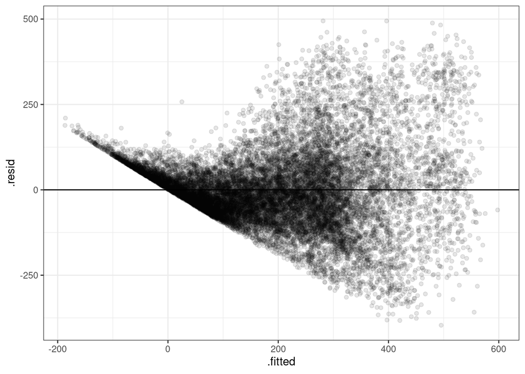

```r
#geom_point() is an alt option for non-transparent dots

ggplot(model7, aes(x = .fitted, y = .resid)) +
  geom_point(alpha = 0.1) +
  geom_hline(yintercept = 0) + theme_bw()
```

Why do we see a pattern like this?

## It is distributed more broadly as we look more into the higher fitted numbers.

Next is a plot of the distribution of residuals. We can use a histogram for this. Ideally, this histogram should look like a Normal distribution.

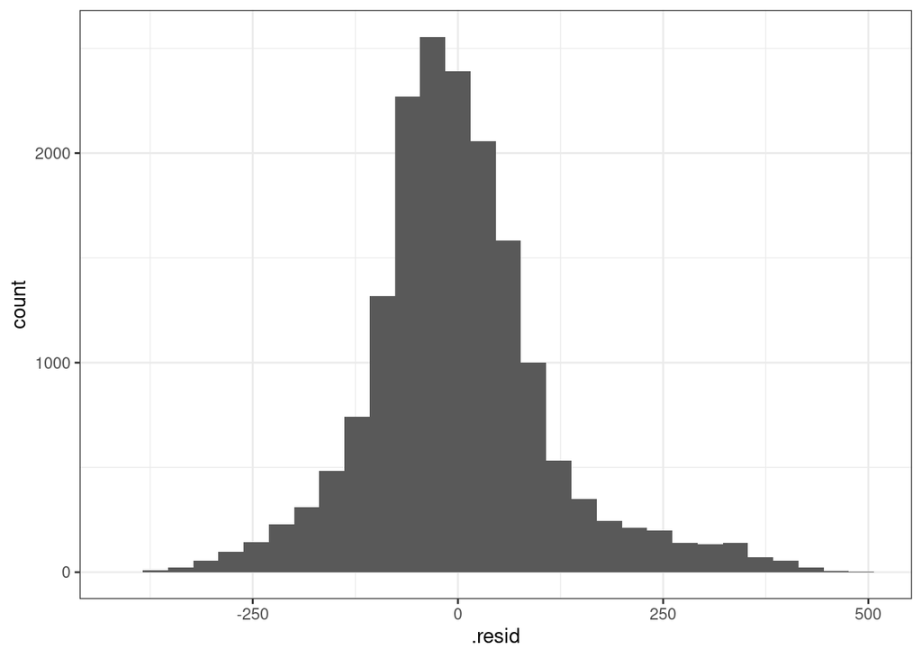

```r
ggplot(model7, aes(x = .resid)) +
  geom_histogram() +
  theme_bw()
```

## Practical implications = pricing, logistics, geo-graphic, fleet size/how many…

This is not too bad!